# Flat, yet deep - How treemaps can be used to visualize complex data

Before we dive directly into the fun of making treemaps, one word regarding the past, present and future of this blog. The last post I made is around one year ago (so much for the past). Many things have happened in this year, first and foremost that I became father for the second time.

Both family life and my professional life as researcher at Science for Life Lab in Stockholm do in fact leave only limited time for extra activities, like this blog. This is a bit sad for me, but I see it as a temporary issue. I’m still more than dedicated to this blog (present) and will try to post more regularly in the future. Particularly because so many interesting things are happening in the data sciences, and these things have also changed the way I conduct my research and work with data. Just to name of few, I started using [github](https://github.com/m-jahn/) and making my own R packages. I want to write and publish my data analysis pipelines as R markdown notebooks. I want to get more familiar with machine learning, and so on. All of these developments are worth their own posts, but now I start with: treemaps.

What are treemaps? Treemaps are extremely space-efficient yet easy to grasp visualizations for data sets with two important properties: The data can have both *numerical* and *categorial* character. The *numerical part determines the **map** in treemap*, that means tiles or cells of a 2-dimensional plane are scaled according to the input. Small values become small cells and large values become large cells. The *categorial part determines the **tree** in treemap*, that means one big cell can in turn be parent to a set of smaller cells that are nested within it. Well, a picutre is worth a thousand words so let’s look at an example.

Based on existing functions I have compiled an R package for creation of **Voronoi and Sunburst treemaps**, [**SysbioTreemaps**](https://github.com/m-jahn/SysbioTreemaps), available on github and maybe sooner or later on CRAN. Let’s test it.

#### Installing the package

```r
# install SysbioTreemaps from github
require(devtools)
devtools::install_github("https://github.com/m-jahn/SysbioTreemaps")

# attach packages
library(SysbioTreemaps)
library(tidyverse)
```

#### A simple example

We can use the `starwars` data set from the `dplyr` package. It’s good for our purpose because it contains both numeric and categorial data. The latter are name and home world of the movie characters. The cell size for each character is encoded by the number of films he or she showed up in.

[figure not shown]

```r
df <- dplyr::starwars %>%
  mutate(films = films %>% sapply(length)) %>%
  mutate(name = substr(name, 1, 20)) %>%
  filter(!is.na(homeworld))

# generate voronoi treemap
tm <- voronoiTreemap(
  data = df,
  levels = c("homeworld", "name"),
  cell_size = "films",
  shape = "rounded_rect",
  positioning = "clustered_by_area"
)
# draw the treemap
drawTreemap(tm,
  label_level = 1:2,
  label_color = c(grey(0.95), grey(0.85)),
  label_size = c(2, 2)
)
```

So what happened? In treemap logic, the total area of the plane was subdivided into parental cells and the area of each of these parents corresponds to the sum of the daughter cell’s area. All cells are therefore either directly scaled according to the numerical variable, or aggregated from daughter cells.

#### A real world data set

This blog is called Europe by Numbers for a reason. I like to explore data as much as I like to explore European countries. I have often used **Eurostat** as a source for data regarding European countries, and now there is the fantastic [eurostat package for R](https://github.com/ropengov/eurostat/). We can search for keywords in the description of databases and then download the table of choice. In this example we search expenditures for consumer goods per EU country.

```r
library(eurostat)
# download data from eurostat: we can search for purchasing power parities
search_eurostat("Purchasing power") %>% pull(title) %>% substr(1, 100)
df <- get_eurostat("prc_ppp_ind", type = "label", stringsAsFactors = FALSE)
```

```r
head(df)
```

| na_item | ppp_cat | geo | time | values |
| --- | --- | --- | --- | --- |
| Nominal expenditure (in euro) | Actual individual consumption | Albania | 2018-01-01 | 10804 |
| Nominal expenditure (in euro) | Actual individual consumption | Austria | 2018-01-01 | 246169 |
| Nominal expenditure (in euro) | Actual individual consumption | Bosnia and Herzegovina | 2018-01-01 | 14643 |
| Nominal expenditure (in euro) | Actual individual consumption | Belgium | 2018-01-01 | 300228 |
| Nominal expenditure (in euro) | Actual individual consumption | Bulgaria | 2018-01-01 | 38585 |
| Nominal expenditure (in euro) | Actual individual consumption | Switzerland | 2018-01-01 | 351582 |

This data set is a time series of consumer goods expenditures from 1995 to 2018, broken down per EU country. We filter the data set for a subset of interesting variables and countries. Particularly, we filter out categories (`ppp_cat`) that seem to be aggregates of sub-categories, for example ‘Total goods’ *et cetera*.

```r
# filter for specific year and member country
df_subset <- df %>% filter(
  na_item == "Nominal expenditure per inhabitant (in euro)",
  !grepl("Total|Capital|Gross|[Ff]inal|Actual|Food and|[Cc]ons|serv", ppp_cat),
  time == "2018-01-01"
)
# abbreviate categories
df_subset <- df_subset %>%
  mutate(ppp_cat = substr(ppp_cat, 1, 25) %>% gsub(" ", "\n", .))
```

Generate treemap and plot it.

```r
# generate voronoi treemap
tm <- voronoiTreemap(
  data = filter(df_subset, geo %in% c("Sweden", "Finland",
    "Denmark", "Iceland", "Estonia", "Lithuania", "Latvia", "Norway")),
  levels = c("geo", "ppp_cat"),
  cell_size = "values",
  shape = "rounded_rect",
  positioning = "clustered_by_area",
  error_tol = 0.001,
  maxIteration = 200
)
```

```
Level 1 tesselation:  0.03 % mean error,  0.1 % max error,  170 iterations
Level 2 tesselation:  0.11 % mean error,  0.53 % max error,  200 iterations
Level 2 tesselation:  0.1 % mean error,  0.36 % max error,  200 iterations
Level 2 tesselation:  0.14 % mean error,  0.57 % max error,  200 iterations
Level 2 tesselation:  0.11 % mean error,  0.38 % max error,  200 iterations
Level 2 tesselation:  0.1 % mean error,  0.5 % max error,  200 iterations
Level 2 tesselation:  0.06 % mean error,  0.28 % max error,  200 iterations
Level 2 tesselation:  0.12 % mean error,  0.96 % max error,  200 iterations
Level 2 tesselation:  0.12 % mean error,  0.54 % max error,  200 iterations
Treemap successfully created
```

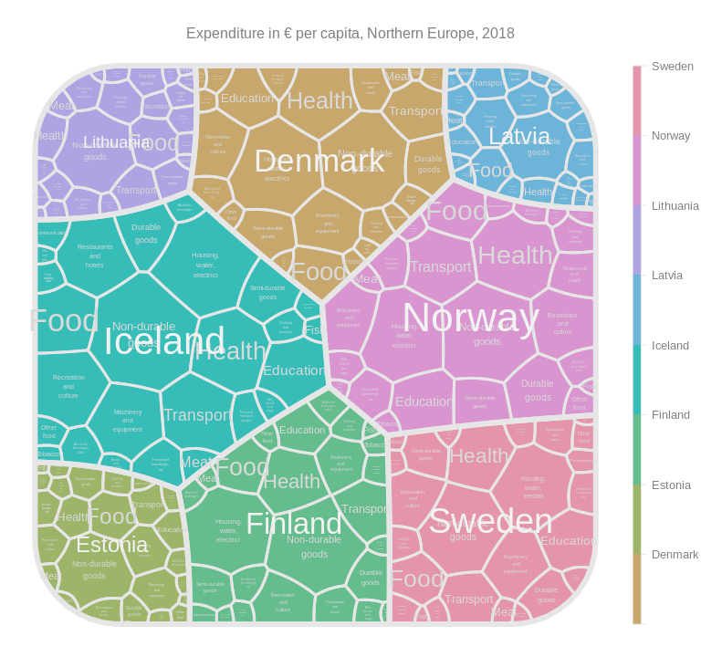

```r
# draw the treemap
drawTreemap(tm,
  label_level = 1:2,
  label_color = c(grey(0.95), grey(0.85)),
  label_size = c(2, 4),
  legend = TRUE,
  title = "Expenditure in € per capita, Northern Europe, 2018"
)
```

The same thing as it would look for Central Europe…

```r
# trim Germanys name
df_subset <- df_subset %>% mutate(geo = gsub("Germany.*", "Germany", geo))
# generate voronoi treemap
tm <- voronoiTreemap(
  data = filter(df_subset, geo %in% c(
      "Germany", "France", "Poland", "Czechia",
      "Netherlands", "Belgium", "Austria", "Switzerland",
      "Germany (until 1990 former territory of the FRG)",
      "Luxembourg"
    )),
  levels = c("geo", "ppp_cat"),
  cell_size = "values",
  shape = "rounded_rect",
  positioning = "clustered_by_area",
  error_tol = 0.001,
  maxIteration = 200
)
```

```
Level 1 tesselation:  0.4 % mean error,  0.96 % max error,  200 iterations
Level 2 tesselation:  0.1 % mean error,  0.35 % max error,  200 iterations
Level 2 tesselation:  0.11 % mean error,  0.89 % max error,  200 iterations
Level 2 tesselation:  0.08 % mean error,  0.43 % max error,  200 iterations
Level 2 tesselation:  0.09 % mean error,  0.3 % max error,  200 iterations
Level 2 tesselation:  0.1 % mean error,  0.65 % max error,  200 iterations
Level 2 tesselation:  0.09 % mean error,  0.34 % max error,  200 iterations
Level 2 tesselation:  0.12 % mean error,  0.47 % max error,  200 iterations
Level 2 tesselation:  0.08 % mean error,  0.48 % max error,  200 iterations
Level 2 tesselation:  0.09 % mean error,  0.73 % max error,  200 iterations
Treemap successfully created
```

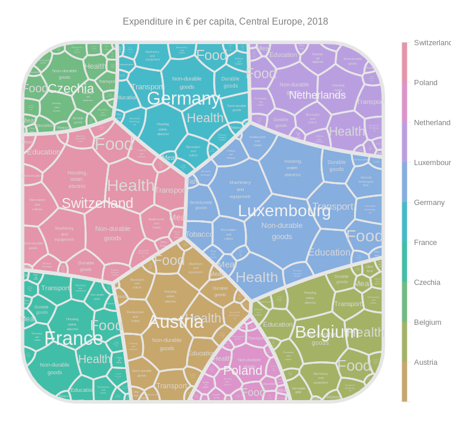

```r
# draw the treemap
drawTreemap(tm,
  label_level = 1:2,
  label_color = c(grey(0.95), grey(0.85)),
  label_size = c(2, 4),
  legend = TRUE,
  title = "Expenditure in € per capita, Central Europe, 2018"
)
```